# DDG2P에서 pLI와 allelic requirement에 따른 mutation consequence

```r
library(tidyverse)
library(ggplot2)
library(ggridges)
library(ggthemes)

d <- read.table("DDG2P_24_9_2019.with_pLI.txt", sep='\t', header = T)

d %>%
  filter(!is.na(mutation.consequence)) %>%
  ggplot(aes(pLI, str_wrap(mutation.consequence, 15))) +
  geom_density_ridges(aes(fill=mutation.consequence), alpha=.7) +
  labs(x="pLI score", y="Mutation consequence", fill="Mutation consequence", title = "Mutation consequence with pLI&allelic requirement in DDG2P") +
  facet_wrap(~allelic.requirement, ncol=6)
```

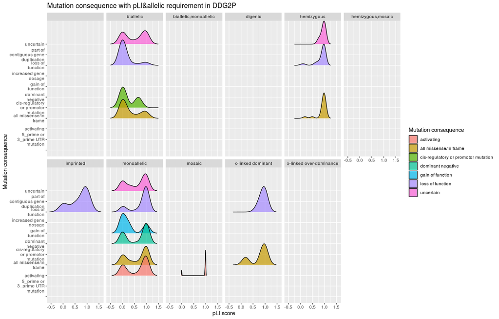

DDG2P에서 pLI score과 allelic requirement에 따라 mutation consequence가 어떻게 분포하는지를 plot에 나타내보았다. x축에 pLI score을 나타낸 뒤 y축에 mutation consequence의 종류를 나타내어 pLI score에 따라 mutation score이 어떻게 분포하는지 표시한 후, allelic requirement에 따라 faceting하였다.

plot으로 나타난 것을 살펴보면, biallelic을 제외한 allelic requirement에서 pLI가 클수록 LOF의 분포가 늘어나며 LOF가 아닌 다른 mutation consequence 또한 pLI가 클수록 분포가 커진다는 것을 확인할 수 있다. 단 예외로, gain of function은 allelic requirement가 monoallelic인 경우 pLI가 더 작은 경우에 많이 분포해 있다. 이것으로 pLI가 클수록 LOF뿐만 아니라 다른 mutation에도 취약한 것은 아닐까 하는 추측을 하게 되었다.

pLI는 유전자가 LOF에 취약한 정도를 나타내는 수치이다. 그러나 plot에서 확인할 수 있듯이, 모든 경우에 pLI가 클수록 많은 수의 LOF가 분포해 있지는 않으며, gain of function의 경우와 biallelic에서의 많은 mutation 또한 pLI와 분포가 비례하지 않는다.

plot에 이렇게 나타난 이유를 알아보기 위해 자료를 찾아보았는데, [A snapshot of some pLI score pitfalls](https://library.korea.ac.kr/auth/outlink?moduleId=eds&linkType=clink&targetUrl=https%3A%2F%2Fonlinelibrary.wiley.com%2Fdoi%2Fabs%2F10.1002%252Fhumu.23763%3F)에서는 pLI 값에 오류가 발생하기 쉬운 경우와 주의해야 할 점에 대해 나와 있다. 첫 번째로, pLI는 상염색체 열성 장애인 경우 적절히 적용되지 않고, 둘째로 성인이 되어 생식을 하기까지 큰 영향을 미치지 않는 유전자의 변화인 경우 또한 예측한 pLI 값과는 차이가 있는 결과를 얻을 수 있다. 셋째로, splice donor나 splice acceptor 장소에서 발생하는 variants는 splicing에 미치는 영향이 무엇인지 특정되지 않았을 때에도 protein truncating variant로 여겨지기 때문에 pLI값이 부정확해질 수 있다.

앞서 나온 이유들로 보아, pLI는 LOF 또는 그 외의 다른 mutation의 여부에 대한 절대적인 판단 기준이 될 수 없다. 즉 pLI가 작은 경우에도 mutation이 발생하고 그에 따라 disorder이 발생할 수 있다. biallelic의 대부분과 gain of function이 pLI가 큰 경우에 분포하지 않고 오히려 그 반대인 것 또한 이런 이유일 것이다.

pLI가 큰 경우 LOF에 더 취약하고, 그에 따라 mutation이 발생할 확률이 높아지지만 plot에서도 확인할 수 있듯이, pLI가 작다고 disorder이 발생하지 않는다는 것이 아니라는 것을 알았다. 따라서 mutation의 유무를 확인하고 싶다면 단순히 pLI로만 판단하는 것이 아니라 여러 요소를 조합해 확인하는 것이 좋을 것이라는 것 또한 알게 되었다. 특히 plot에서 biallelic인 경우 pLI 값이 0에 가까울수록 LOF가 많이 발생한 것과, gain of function의 경우는 biallelic이 아닌 경우에도 pLI 값이 0에 가까운 곳에 주로 분포되어 있는 것이 이러한 확인의 필요성을 나타내준다. 이 plot에서는 allelic requirement가 biallelic인 경우와 mutation consequence가 gain of function인 경우에 주의할 필요가 있다는 것을 알 수 있지만, DDG2P의 다른 data를 이용한다면 이 외에도 다른 고려 사항들을 더 찾아낼 수 있을 것이다.